# 00_FastQC

Yuan Karina Zhang

2026-03-13

```r
pacman::p_load(tidyverse, dada2, phyloseq, patchwork,
               DT, devtools, Biostrings, ShortRead,
               install = FALSE)
```

```r
raw_fastqs_path <- "/local/workdir/yz3272/BIOMI6300_IronMicrobiotaProject/Raw_seq"
raw_fastqs_path
```

```
## [1] "/local/workdir/yz3272/BIOMI6300_IronMicrobiotaProject/Raw_seq"
```

```r
head(list.files(raw_fastqs_path))
```

```
## [1] "01_trimmingfiltering"   "SRR29920099_1.fastq.gz" "SRR29920099_2.fastq.gz"
## [4] "SRR29920100_1.fastq.gz" "SRR29920100_2.fastq.gz" "SRR29920101_1.fastq.gz"
```

```r
length(list.files(raw_fastqs_path))
```

```
## [1] 205
```

```r
# Create vector of forward reads
forward_reads <- list.files(raw_fastqs_path, pattern = "_1.fastq.gz", full.names = TRUE)

# Intuition Checks
head(forward_reads)
```

```
## [1] "/local/workdir/yz3272/BIOMI6300_IronMicrobiotaProject/Raw_seq/SRR29920099_1.fastq.gz"
## [2] "/local/workdir/yz3272/BIOMI6300_IronMicrobiotaProject/Raw_seq/SRR29920100_1.fastq.gz"
## [3] "/local/workdir/yz3272/BIOMI6300_IronMicrobiotaProject/Raw_seq/SRR29920101_1.fastq.gz"
## [4] "/local/workdir/yz3272/BIOMI6300_IronMicrobiotaProject/Raw_seq/SRR29920102_1.fastq.gz"
## [5] "/local/workdir/yz3272/BIOMI6300_IronMicrobiotaProject/Raw_seq/SRR29920103_1.fastq.gz"
## [6] "/local/workdir/yz3272/BIOMI6300_IronMicrobiotaProject/Raw_seq/SRR29920104_1.fastq.gz"
```

```r
# Intuition check #2: We should have fewer reads in the forward vector than in total
stopifnot(length(forward_reads) < length(list.files(raw_fastqs_path)))

# Create a vector of reverse reads
reverse_reads <- list.files(raw_fastqs_path, pattern = "2.fastq.gz", full.names = TRUE)

# Intuition Checks
head(reverse_reads)
```

```
## [1] "/local/workdir/yz3272/BIOMI6300_IronMicrobiotaProject/Raw_seq/SRR29920099_2.fastq.gz"
## [2] "/local/workdir/yz3272/BIOMI6300_IronMicrobiotaProject/Raw_seq/SRR29920100_2.fastq.gz"
## [3] "/local/workdir/yz3272/BIOMI6300_IronMicrobiotaProject/Raw_seq/SRR29920101_2.fastq.gz"
## [4] "/local/workdir/yz3272/BIOMI6300_IronMicrobiotaProject/Raw_seq/SRR29920102_2.fastq.gz"
## [5] "/local/workdir/yz3272/BIOMI6300_IronMicrobiotaProject/Raw_seq/SRR29920103_2.fastq.gz"
## [6] "/local/workdir/yz3272/BIOMI6300_IronMicrobiotaProject/Raw_seq/SRR29920104_2.fastq.gz"
```

```r
# Intuition check #2: Need to have equal number of forward and reverse files
stopifnot(length(reverse_reads) == length(forward_reads))
```

```r
# Randomly select 12 samples from dataset to evaluate
# Selecting 12 is typically better than 2 (like we did in class for efficiency)
random_samples <- sample(1:length(reverse_reads), size = 12)
random_samples
```

```
##  [1] 59 45 49 80 92 40 68  8 43 95  5 55
```

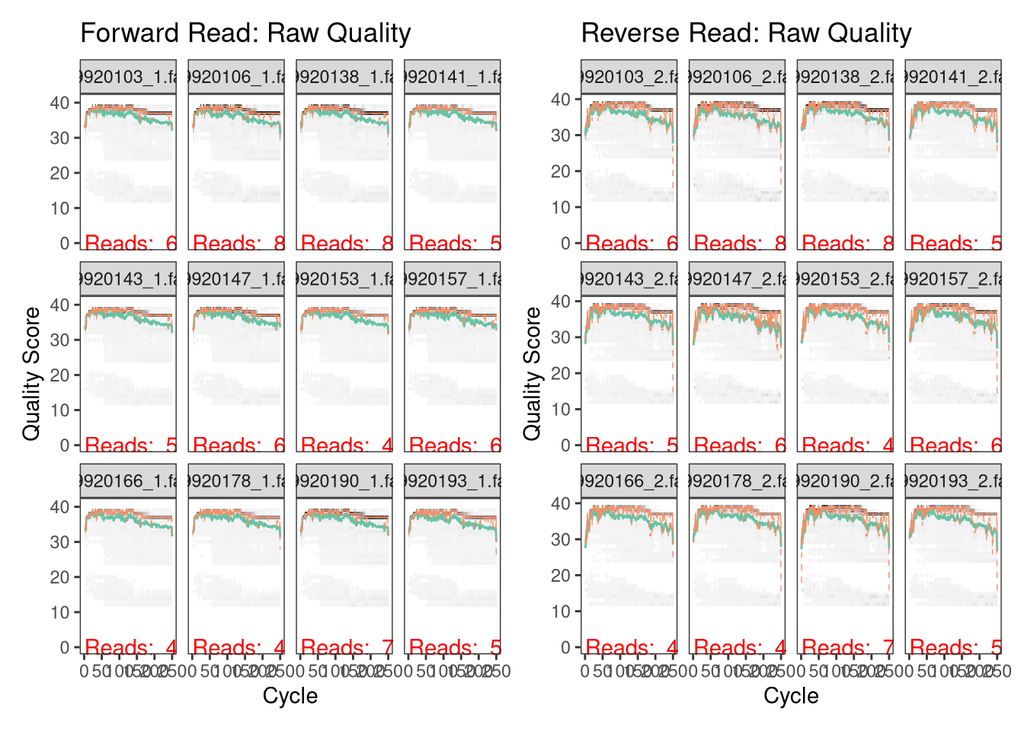

```r
# Calculate and plot quality of these two samples
forward_filteredQual_plot_12 <- plotQualityProfile(forward_reads[random_samples]) +
  labs(title = "Forward Read: Raw Quality")
reverse_filteredQual_plot_12 <- plotQualityProfile(reverse_reads[random_samples]) +
  labs(title = "Reverse Read: Raw Quality")

# Plot them together with patchwork
forward_filteredQual_plot_12 + reverse_filteredQual_plot_12
```

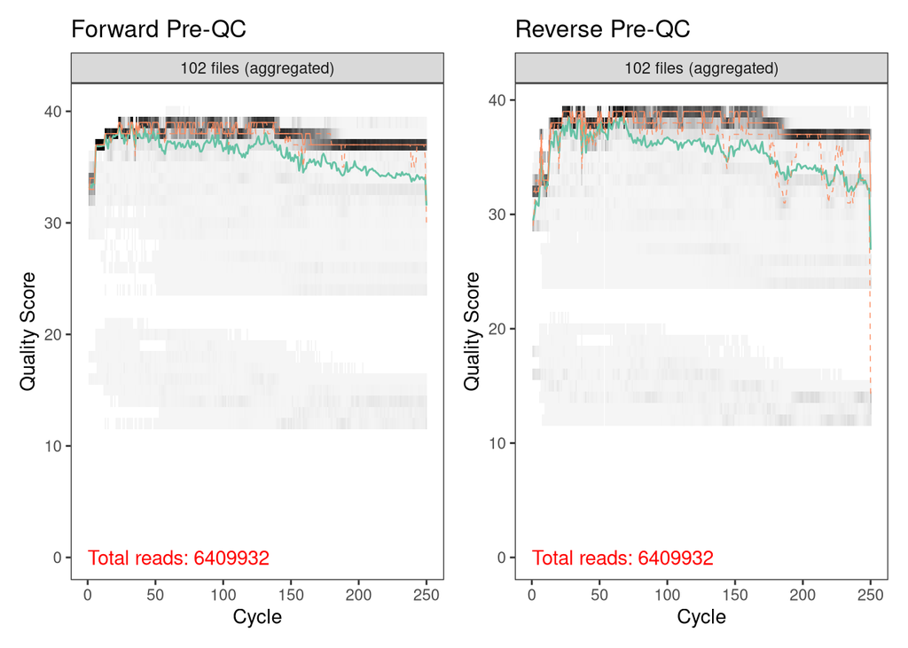

```r
# Aggregate all QC plots
# Forward reads
forward_preQC_plot <-
  plotQualityProfile(forward_reads, aggregate = TRUE) +
  labs(title = "Forward Pre-QC")

# reverse reads
reverse_preQC_plot <-
  plotQualityProfile(reverse_reads, aggregate = TRUE) +
  labs(title = "Reverse Pre-QC")

# Now, let's put the two plots together
preQC_aggregate_plot <-
  # Plot the forward and reverse together
  forward_preQC_plot + reverse_preQC_plot
# Show the plot
preQC_aggregate_plot
```

# Interpretation of Pre-QC quality: The forward and reverse reads have good quality overall, as we discussed, minor drop in quality was saw in the beginning of sequences, with more decline at the tail, such trends were more protrude in the reverse reads whose final tail regions had greater drop of Phred score. These observations suggest the tail portion (~10 bps) will need to be trimmed to enhance the quality. Also need to assess if the primers present to decide the length for trimming.

```r
# Search the sequences for primers to check if they are present
# Pull out the raw_fastq sequences from all of the raw sequencing files
raw_fastqs <- readFastq(dirPath = raw_fastqs_path)
# The above code makes a complex S3 object.Let's only grab the DNA sequences
all_seqs <- sread(raw_fastqs)

# The primer sequences that were used for the in class dataset.
# NOTE: YOU WILL NEED TO MODIFY THE CODE TO MATCH THE PRIMERS USED IN YOUR DATASET!
f_primer <- "GGMTTAGATACCCBDGTA"
r_primer <- "GGGTYKCGCTCGTTR"

# Search the dataset: OFFICE HOUR what is the purpose of this?
# Check the complement of the primers
Fprimer_complement <- complement(DNAString(f_primer))
Fprimer_revComplement <- reverseComplement(DNAString(f_primer))

Rprimer_complement <- complement(DNAString(r_primer))
Rprimer_revComplement <- reverseComplement(DNAString(r_primer))

# Test an example on one sequence randomly selected from a forward read: SRR29920099
test_DNAseq <- DNAString("CCACGCCGTAAACGATGAGGACCATGTGTTGGGGGTGTAACCTCTGTGCTGAAGTTAACGCAGTGAGTCCTCCGCCTGGGGAGTATGCACGCAAGTGTGA")

# Test code now
matchPattern(
  pattern = "GGMTTAGATACCCBDGTA",
  subject = DNAString("GGATTAGATACCCCGGTA"),
  fixed = FALSE
)
```

```
## Views on a 18-letter DNAString subject
## subject: GGATTAGATACCCCGGTA
## views:
##       start end width
##   [1]     1  18    18 [GGATTAGATACCCCGGTA]
```

```r
############ POSITIVE CONTROLS OF CODE TO MAKE SURE IT WORKS ############
all_f_hits <- c()

for (f in forward_reads) {
  fq <- readFastq(f)
  seqs <- sread(fq)

  hits <- vcountPattern("GGMTTAGATACCCBDGTA", seqs, fixed = FALSE)
  all_f_hits <- c(all_f_hits, hits > 0)
}

paste("Forward primer is found in",
      round(mean(all_f_hits) * 100, 2),
      "% of forward sequences")
```

```
## [1] "Forward primer is found in 97.99 % of forward sequences"
```

```r
############ POSITIVE CONTROLS OF CODE TO MAKE SURE IT WORKS ############
# Let's use a sequence that is very conserved and def present
all_r_hits <- c()

for (r in reverse_reads) {
  fq <- readFastq(r)
  seqs <- sread(fq)

  hits <- vcountPattern("GGGTYKCGCTCGTTR", seqs, fixed = FALSE)
  all_r_hits <- c(all_r_hits, hits > 0)
}

paste("Reverse primer is found in",
      round(mean(all_r_hits) * 100, 2),
      "% of reverse sequences")
```

```
## [1] "Reverse primer is found in 93.09 % of reverse sequences"
```

# Interpertation of primer evaluation:

```r
# When there is a match, vmatchPattern can be used to locate the indices of the matches
#test_pos_control <-
  vmatchPattern(pattern = "CGGAATTACTGGGCG",
                subject = all_seqs,
                fixed = FALSE)
```

```
## MIndex object of length 12819864
## [[1]]
## IRanges object with 0 ranges and 0 metadata columns:
##        start       end     width
##    <integer> <integer> <integer>
##
## [[2]]
## IRanges object with 0 ranges and 0 metadata columns:
##        start       end     width
##    <integer> <integer> <integer>
##
## [[3]]
## IRanges object with 0 ranges and 0 metadata columns:
##        start       end     width
##    <integer> <integer> <integer>
##
## ...
## <12819861 more elements>
```

```r
# Take a look
#head(test_pos_control)
```

```r
# Create vector of sample names from the filenames
sample_names <- sapply(strsplit(basename(forward_reads), "_"), `[`,1)

# Intuition Check
head(sample_names)
```

```
## [1] "SRR29920099" "SRR29920100" "SRR29920101" "SRR29920102" "SRR29920103"
## [6] "SRR29920104"
```

```r
# Place filtered reads into filtered_fastqs_path
filtered_path <- file.path(raw_fastqs_path, "01_trimmingfiltering")

# Intuition Check
filtered_path
```

```
## [1] "/local/workdir/yz3272/BIOMI6300_IronMicrobiotaProject/Raw_seq/01_trimmingfiltering"
```

```r
# create 2 vectors: filtered_forward_reads & filtered_reverse_reads
filtered_forward_reads <-
  file.path(filtered_path, paste0(sample_names, "_R1_filtered.fastq.gz"))

filtered_reverse_reads <-
  file.path(filtered_path, paste0(sample_names, "_R2_filtered.fastq.gz"))

# Intuition Check
length(filtered_forward_reads)
```

```
## [1] 102
```

```r
head(filtered_forward_reads)
```

```
## [1] "/local/workdir/yz3272/BIOMI6300_IronMicrobiotaProject/Raw_seq/01_trimmingfiltering/SRR29920099_R1_filtered.fastq.gz"
## [2] "/local/workdir/yz3272/BIOMI6300_IronMicrobiotaProject/Raw_seq/01_trimmingfiltering/SRR29920100_R1_filtered.fastq.gz"
## [3] "/local/workdir/yz3272/BIOMI6300_IronMicrobiotaProject/Raw_seq/01_trimmingfiltering/SRR29920101_R1_filtered.fastq.gz"
## [4] "/local/workdir/yz3272/BIOMI6300_IronMicrobiotaProject/Raw_seq/01_trimmingfiltering/SRR29920102_R1_filtered.fastq.gz"
## [5] "/local/workdir/yz3272/BIOMI6300_IronMicrobiotaProject/Raw_seq/01_trimmingfiltering/SRR29920103_R1_filtered.fastq.gz"
## [6] "/local/workdir/yz3272/BIOMI6300_IronMicrobiotaProject/Raw_seq/01_trimmingfiltering/SRR29920104_R1_filtered.fastq.gz"
```

```r
length(filtered_reverse_reads)
```

```
## [1] 102
```

```r
head(filtered_reverse_reads)
```

```
## [1] "/local/workdir/yz3272/BIOMI6300_IronMicrobiotaProject/Raw_seq/01_trimmingfiltering/SRR29920099_R2_filtered.fastq.gz"
## [2] "/local/workdir/yz3272/BIOMI6300_IronMicrobiotaProject/Raw_seq/01_trimmingfiltering/SRR29920100_R2_filtered.fastq.gz"
## [3] "/local/workdir/yz3272/BIOMI6300_IronMicrobiotaProject/Raw_seq/01_trimmingfiltering/SRR29920101_R2_filtered.fastq.gz"
## [4] "/local/workdir/yz3272/BIOMI6300_IronMicrobiotaProject/Raw_seq/01_trimmingfiltering/SRR29920102_R2_filtered.fastq.gz"
## [5] "/local/workdir/yz3272/BIOMI6300_IronMicrobiotaProject/Raw_seq/01_trimmingfiltering/SRR29920103_R2_filtered.fastq.gz"
## [6] "/local/workdir/yz3272/BIOMI6300_IronMicrobiotaProject/Raw_seq/01_trimmingfiltering/SRR29920104_R2_filtered.fastq.gz"
```

```r
filtered_reads <-
  filterAndTrim(fwd = forward_reads, filt = filtered_forward_reads,
              rev = reverse_reads, filt.rev = filtered_reverse_reads,
              maxN = 0, maxEE = c(2,2),
              trimLeft = c(18,15),
              truncLen = c(230, 220),
              truncQ = 2, rm.phix = TRUE, compress = TRUE,
              multithread = 32)
```

# Justification of parameters used:

The trimming process start with removing primers, and my forward primers consist of 18bps, with the reverse primer hacving 15 bps. Truncating at 230 and 220 keeps most of the high-quality sequence and removes the weaker 3′ ends, due to observed low quality at the end in the reverse sequences. The primers were short and with 250bps sequencing length, there is sufficient overlaps for combination of R1 and R2.Other parameters were selected based on our discussion in lab session.

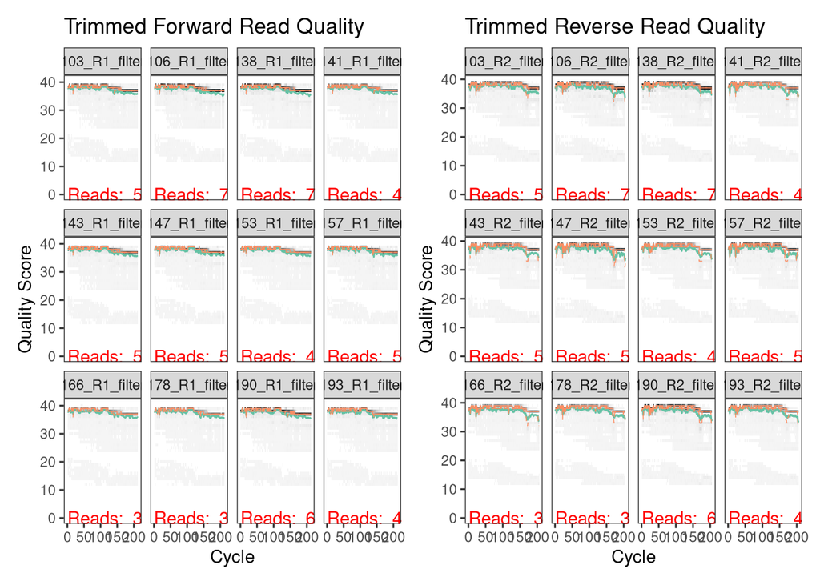

```r
# Plot the 12 random samples after QC
forward_filteredQual_plot_12 <-
  plotQualityProfile(filtered_forward_reads[random_samples]) +
  labs(title = "Trimmed Forward Read Quality")

reverse_filteredQual_plot_12 <-
  plotQualityProfile(filtered_reverse_reads[random_samples]) +
  labs(title = "Trimmed Reverse Read Quality")

# Put the two plots together
forward_filteredQual_plot_12 + reverse_filteredQual_plot_12
```

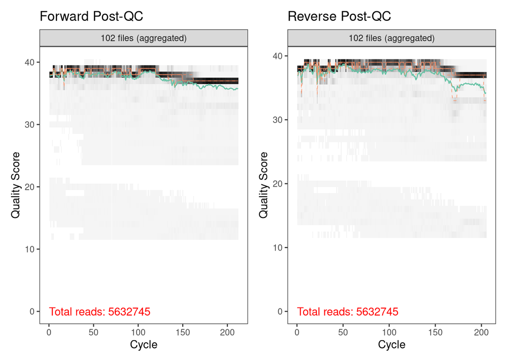

```r
# Aggregate all QC plots
# Forward reads
forward_postQC_plot <-
  plotQualityProfile(filtered_forward_reads, aggregate = TRUE) +
  labs(title = "Forward Post-QC")

# reverse reads
reverse_postQC_plot <-
  plotQualityProfile(filtered_reverse_reads, aggregate = TRUE) +
  labs(title = "Reverse Post-QC")

# Now, let's put the two plots together
postQC_aggregate_plot <-
  # Plot the forward and reverse together
  forward_postQC_plot + reverse_postQC_plot
# Show the plot
postQC_aggregate_plot
```

```r
# SAVE DATA FIRST
 # save(filtered_reads, file = "/local/workdir/yz3272/BIOMI6300_IronMicrobiotaProject/Data/01_trimmingfiltering/filtered_reads.RData")
```

# Interpretation of postQC plots:

PostQC plots showed that aftertrimming, the quality of both forward and reverse sequencing are sig. improved, with most of them fall above score 37. At this point, I think they are ready for downstream DADA2.

```r
# Make output into dataframe
filtered_df <- as.data.frame(filtered_reads) %>%
  mutate(percent.retained = reads.out/reads.in)

# Intuition check --> LACK OF PACKAGE, OFFICE HOUR
# Visualize it in table format
#DT::datatable(filtered_df)

# Let's calculate some statistics
read_stats_df <-
  filtered_df %>%
  reframe(median_reads_in = median(reads.in),
          median_reads_out = median(reads.out),
          median_percent_retained = (median(reads.out)/median(reads.in)),
          max_percent_retained = max(reads.out/reads.in),
          min_percent_retained = min(reads.out/reads.in))

# Take a look at it!
read_stats_df
```

```
##   median_reads_in median_reads_out median_percent_retained max_percent_retained
## 1           62044          53924.5               0.8691332            0.9029507
##   min_percent_retained
## 1            0.8484295
```

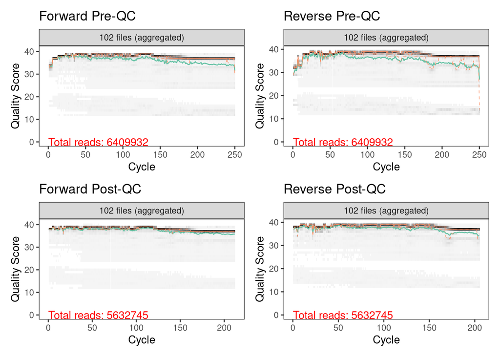

```r
# Plot it
numSeqs_QC_dotplot <-
  filtered_df %>%
  ggplot(aes(x = reads.in, y = reads.out)) +
  geom_point(alpha = 0.5, size = 2) +
  labs(x = "# of Raw Seqs",
       y = "# of Seqs Retained") +
  # Now let's add a 1:1 line for reference of keeping 100% of the reads
  geom_abline(slope=1, intercept = 0, color = "deeppink")

# Now, let's look at the number of reads retained in a histogram
numRetained_QC_histplot <-
  filtered_df %>%
  ggplot(aes(x = reads.out)) +
  geom_histogram() +
  labs(x = "# of Seqs Retained",
       y = "# of Samples")

# Create a histogram of percent reads retained in a histogram
percSeqs_QC_histplot <-
  filtered_df %>%
  ggplot(aes(x = percent.retained)) +
  geom_histogram() +
  labs(x = "% of Seqs Retained",
       y = "# of Samples") +
  # Set the scale to be between 0-1 (0-100%)
  scale_x_continuous(limits = c(0, 1))

# Now, let's put the plots together
PostQC_check <- numSeqs_QC_dotplot + numRetained_QC_histplot + percSeqs_QC_histplot +
  plot_annotation(tag_levels = 'A')

ggsave(filename = "/local/workdir/yz3272/BIOMI6300_IronMicrobiotaProject/Figures/00_QC/PostQC_check.png", plot = PostQC_check, width = 12, height = 6, dpi = 600)
# Plot the pre and post together in one plot
preQC_aggregate_plot / postQC_aggregate_plot
```

```r
# Save pre/post-QC aggregate plot
ggsave(filename = "/local/workdir/yz3272/BIOMI6300_IronMicrobiotaProject/Figures/00_QC/preQC_aggregate_quality_profiles.png", plot = preQC_aggregate_plot, width = 12, height = 6, dpi = 600)

ggsave(filename = "/local/workdir/yz3272/BIOMI6300_IronMicrobiotaProject/Figures/00_QC/postQC_aggregate_quality_profiles.png",
  plot = postQC_aggregate_plot, width = 12, height = 6, dpi = 600)
```

# Interpretation of comparison plot:

Overall, the pre-QC plots indicated good sequencing quality although we saw a declining trend toward the ends of reads, particularly in reverse reads. After trimming and filtering, the post-QC plots showed improved consistency in per-base quality, indicating that low-quality tail regions were effectively removed while preserving most high-quality sequence data. Because approximately 88% of reads were retained, which is acceptable, and I think the QC process at this point has successfully and appropriately cleaned sequences for downstream DADA2 analysis.

```r
all_f_hits <- c()

for (f in filtered_forward_reads) {
  fq <- readFastq(f)
  seqs <- sread(fq)

  hits <- vcountPattern("GGMTTAGATACCCBDGTA", seqs, fixed = FALSE)
  all_f_hits <- c(all_f_hits, hits > 0)
}

paste("Forward primer remains in",
      round(mean(all_f_hits) * 100, 2),
      "% of filtered forward sequences")
```

```
## [1] "Forward primer remains in 0 % of filtered forward sequences"
```

```r
all_r_hits <- c()

for (r in filtered_reverse_reads) {
  fq <- readFastq(r)
  seqs <- sread(fq)

  hits <- vcountPattern("GGGTYKCGCTCGTTR", seqs, fixed = FALSE)
  all_r_hits <- c(all_r_hits, hits > 0)
}

paste("Reverse primer remains in",
      round(mean(all_r_hits) * 100, 2),
      "% of filtered reverse sequences")
```

```
## [1] "Reverse primer remains in 0 % of filtered reverse sequences"
```

```r
## good quality post QC
```